# Solution of linear systems

We now have many ways of looking at system of equations $Ax=b$.

## Case of a square coefficient matrix ($n\times n$)

These are the 'nice' cases where we might hope that a solution to the system $Ax=b$ (i) exists and (ii) is unique.

We can now examine characteristics of such systems.

1. A unique solution will exist under the following conditions (which imply each other):
   - The RREF of $A$ is the identity matrix.
   - The rank of $A$ is $n$.
   - All columns of $A$ are linearly independent.
   - The nullspace and left nullspace of $A$ are both $\{\vec{0}\}$, in particular the nullity of $A$ is 0. NB. other characteristics can be listed - see e.g. theorem 4.8.4 [A&R].

   In such cases the matrix $A$ has columns (or rows) that are a basis for $R^n$. Therefore, there will be a unique solution $x$ for all possible right hand sides $b$.

   These are the cases where $A$ will have an inverse $A^{-1}$ such that $A^{-1}A=I_n$ and $AA^{-1}=I_n$. This inverse can be found as the product of the elementary matrices that reduce $A$ to $I_n$ (i.e. by elimination methods) or can be found using other techniques such as Cramer's rule (inefficient though!). We can establish of $A$ is invertible by computing the determinant; if $det(A)\neq 0 $ then the inverse will exist, otherwise it does not.
2. The system will be inconsistent if the $rank(A)<n$ and $b$ lies outside the column space of $A$.
3. The system will have an infinite number of solutions if the $rank(A)<n$ and $b$ lies within the column space of $A$.

Example 6.1: Solve the following systems.

$$ \begin{align*} (a)& \quad \begin{bmatrix} 1 & 2 & 0 \\ 4 & 5 & 6 \\ 7 & 8 & 9\end{bmatrix} \begin{bmatrix}x_1 \\ x_2 \\ x_3\end{bmatrix} = \begin{bmatrix} 7 \\ 4 \\ 9\end{bmatrix} \cr\cr\cr (b)& \quad \begin{bmatrix} 1 & 2 & 3 \\ 4 & 5 & 6 \\ 7 & 8 & 9\end{bmatrix} \begin{bmatrix}x_1 \\ x_2 \\ x_3\end{bmatrix} = \begin{bmatrix} 5 \\ 7 \\ 9\end{bmatrix} \cr\cr\cr (c)& \quad \begin{bmatrix} 1 & 2 & 3 \\ 4 & 5 & 6 \\ 7 & 8 & 9\end{bmatrix} \begin{bmatrix}x_1 \\ x_2 \\ x_3\end{bmatrix} = \begin{bmatrix} 7 \\ 4 \\ 9\end{bmatrix} \end{align*} $$

```matlab
# case (a)
A=[1 2 0; 4 5 6; 7 8 9];
b=[7 4 9]';
rref([A,b]);
rank(A);
A\b;

# case (b)
A=[1 2 3; 4 5 6; 7 8 9];
b=[5 7 9]';
rref([A,b]);
A\b;
b=[3 9 15]';
# consider what the following does...?
A\b;

# case (c)
A=[1 2 3; 4 5 6; 7 8 9];
b=[7 4 9]';
rref([A,b]);
rank(A);
# consider what the following does...?
A\b;
```

```
warning: matrix singular to machine precision
warning: matrix singular to machine precision
```

## Case of a underdetermined system: ($m\times n$) coefficient matrix with $m<n$

Here there are more unknown than equations. The characteristics here are:

1. Rank of $A$ must be less than the number of unknowns and therefore there will be free variables.
2. The right hand side will be consistent if it lies within the column space of $A$, and in such a case there will be a infinite number of solutions.
3. The right hand side may lie outside the column space of $A$, in which case the system in inconsistent.
4. If $rank(A)=m$ then the system will be consistent for all right hand sides $b$.

Example 6.2: Solve the following systems.

$$ \begin{align*} (a)& \quad \begin{bmatrix} 1 & 2 & 3 & 4 \\ 5 & 6 & 0 & 8 \\ 9 & 10 & 0 & 12\end{bmatrix} \begin{bmatrix}x_1 \\ x_2 \\ x_3\\ x_4\end{bmatrix} = \begin{bmatrix} 4 \\ 6 \\ 12\end{bmatrix} \cr\cr\cr (b)& \quad \begin{bmatrix} 1 & 2 & 3 & 4 \\ 5 & 6 & 7 & 8 \\ 9 & 10 & 11 & 12\end{bmatrix} \begin{bmatrix}x_1 \\ x_2 \\ x_3\\ x_4\end{bmatrix} = \begin{bmatrix} 4 \\ 6 \\ 12\end{bmatrix} \cr\cr\cr (c)& \quad \begin{bmatrix} 1 & 2 & 3 & 4 \\ 5 & 6 & 7 & 8 \\ 9 & 10 & 11 & 12\end{bmatrix} \begin{bmatrix}x_1 \\ x_2 \\ x_3\\ x_4\end{bmatrix} = \begin{bmatrix} 7 \\ 19 \\ 31\end{bmatrix} \end{align*} $$

```matlab
## case (a)
A=[1 2 3 4; 5 6 0 8; 9 10 0 12];
rank(A);
# what doe the following show...?
rref(A);
rref(A(:,[2,3,4,1]));
rref(A(:,[1,3,4,2]));
rref(A(:,[1,2,4,3]));
b=[4 6 12]';

rref([A,b]);
A\b;
# check
c=A\b;
A*c;
# another solution?
d=[3 -3/2 4/3 0]';
A*d;
```

```matlab
## case (b)
A=[1 2 3 4; 5 6 7 8; 9 10 11 12];
rank(A);
rref(A);
b=[4 6 12]';
rref([A,b]);
A\b;
# check
c=A\b;  # NB: getting least squares solution!
A*c;
```

```matlab
## case (c)
A=[1 2 3 4; 5 6 7 8; 9 10 11 12];
rank(A);
rref(A);
b=[7 19 31]';
rref([A,b]);
A\b;
# check
c=A\b;
A*c;
# another solution?
d=[-1 4 0 0]';
A*d;
```

## Case of an overdetermined system: ($m\times n$) coefficient matrix with $m>n$

Here there are more equations than unknowns. The characteristics here are:

1. Rank of $A$ must be less than or equal to the number of unknowns and therefore there may or may not be free variables.
2. If $rank(A)<n$ there will be free variables and if the system is consistent, then there will be a infinite number of solutions.
3. The right hand side may lie outside the column space of $A$, in which case the system in inconsistent. [We might expect this to be the case most often! Think of the geometry of a $3\times 2$ system.]
4. If $rank(A)=n$ and the system is consistent, then there will be a unique solution.
5. The column space cannot span $R^m$, therefore there will be right hand side solutions that lead to the system being inconsistent.

Example 6.3: Solve the following systems.

$$ \begin{align*} (a)& \quad \begin{bmatrix} 1 & 5 & 9 \\ 2 & 6 & 10 \\ 3 & 0 & 0 \\ 4 & 8 & 12\end{bmatrix} \begin{bmatrix}x_1 \\ x_2 \\ x_3\end{bmatrix} = \begin{bmatrix} 4 \\ 6 \\ 12\\ 10 \end{bmatrix} \cr\cr\cr (b)& \quad \begin{bmatrix} 1 & 5 & 9 \\ 2 & 6 & 10 \\ 3 & 0 & 0 \\ 4 & 8 & 12\end{bmatrix} \begin{bmatrix}x_1 \\ x_2 \\ x_3\end{bmatrix} = \begin{bmatrix} 4 \\ 6 \\ 12\\ 5 \end{bmatrix} \cr\cr\cr (c)& \quad \begin{bmatrix} 1 & 5 & 9 \\ 2 & 6 & 10 \\ 3 & 7 & 11 \\ 4 & 8 & 12\end{bmatrix} \begin{bmatrix}x_1 \\ x_2 \\ x_3\end{bmatrix} = \begin{bmatrix} 7 \\ 6 \\ 5\\ 4 \end{bmatrix} \cr\cr\cr (c)& \quad \begin{bmatrix} 1 & 5 & 9 \\ 2 & 6 & 10 \\ 3 & 7 & 11 \\ 4 & 8 & 12\end{bmatrix} \begin{bmatrix}x_1 \\ x_2 \\ x_3\end{bmatrix} = \begin{bmatrix} 7 \\ 6 \\ 5\\ 8 \end{bmatrix} \end{align*} $$

```matlab
## case (a)
A=[1 2 3 4; 5 6 0 8; 9 10 0 12]';
rank(A);
b=[4 6 12 10]';
rref([A,b]);
# check
c=A\b;
A*c;
```

```matlab
## case (b)
A=[1 2 3 4; 5 6 0 8; 9 10 0 12]';
rank(A);
b=[4 6 12 5]';
rref([A,b]);
# check
c=A\b;
A*c;
```

```matlab
## case (c)
A=[1 2 3 4; 5 6 7 8; 9 10 11 12]';
rank(A);
b=[7 6 5 4]';
rref([A,b]);
A\b;
```

```matlab
## case (d)
A=[1 2 3 4 ; 5 6 7 8; 9 10 11 12]';
b=[7 6 5 8]';
rref([A,b]);
A\b;
```

## A note on the least squares solution

Very often we expect that overdetermined systems will not have a solution, i.e. will be inconsistent.

One 'work around' that can be used in such cases is to get an approximate solution. A very commonly used approximation is the **least squares** method.

We want to solve $$ Ax=b $$ for an $m\times n$ matrix $A$ where $m>n$. The problem is that for most right hand sides, the vector $b$ will not be in the column space of $A$ and hence the system will be inconsistent.

What is the 'closest' vector $\bar{b}$ to $b$ that is in the column space of $A$?

By 'closest' we mean the vector that minimises $||\bar{b}-b||$. Since $\bar{b}$ can be written as $A\bar{x}$ we can equivalently state the quantity to be minimised as $||A\bar{x}-b||$. This is a measure of the squared distance between the vector $b$ and the vector $A\bar{x}$ in the column space, i.e. choose $\bar{b}$ to minimise $[A\bar{x}-b]'[A\bar{x}-b]$. The closest vector will be the orthogonal projection of $b$ onto the column space.

We get the following result:

$$\begin{align*} \bar{x}&=(A^TA)^{-1}A^{T}b\cr\cr \bar{b}&=A(A^TA)^{-1}A^{T}b \end{align*} $$

This is the famous least squares formula and is used in may areas, most famously in statistical linear regression analysis.

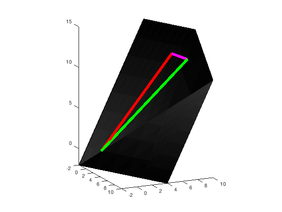

```matlab
graphics_toolkit ("fltk");
set(gcf,'Visible','on')
A=[1 2 3; 5 6 7]';
b=[7 6 13]';
rref([A,b]);
A\b;
xbar=inv(A'*A)*A'*b;
bbar=A*xbar;
x=[-10 -10 20 20]';
y=[-10 20 20 -10]';
z=[-10 50 20 -40]';
patch(x,y,z,[.192 .192 .192]);
view(65,15)
axis([-2,10,-2,10,-2,15],"equal")
hold on;
line([0 7],[0 6],[0, 13],'linewidth',4,'color','red');
line([0 bbar(1)],[0 bbar(2)],[0,bbar(3)],'linewidth',4,'color','green')
line([b(1) bbar(1)],[b(2) bbar(2)],[b(3),bbar(3)],'linewidth',4,'color','magenta')
```

The least squares solution above assumes that the matrix $A$ has maximum rank (i.e. full column rank). If this is not the case, then Octave will use a pseudo-inverse (a.k.a. Moore-Penrose inverse, among other names) solution. The pseudo inverse solution details will not be discussed here.